# Gene Review Statistics Dashboard

Comprehensive statistical analysis of gene annotation reviews across species, evidence types, and curation actions.

## Overview

This notebook analyzes the results of AI-assisted gene annotation curation, where existing Gene Ontology (GO) annotations are systematically reviewed and assigned one of several curation actions:

- **ACCEPT**: The annotation is correct and should be retained as-is
- **MODIFY**: The annotation captures the right concept but needs refinement (e.g., more specific or general term)
- **REMOVE**: The annotation is incorrect or unsupported and should be deleted
- **KEEP_AS_NON_CORE**: The annotation is valid but represents a secondary/contextual function
- **MARK_AS_OVER_ANNOTATED**: The annotation is technically correct but represents an over-interpretation

The analyses below help identify patterns in annotation quality across different evidence types, species, and GO terms.

```python
import pandas as pd
import numpy as np
import matplotlib.pyplot as plt
import seaborn as sns
from pathlib import Path
import warnings
warnings.filterwarnings('ignore')

# Set style for beautiful visualizations
plt.style.use('seaborn-v0_8-darkgrid')
sns.set_palette("husl")
plt.rcParams['figure.figsize'] = (12, 6)
plt.rcParams['font.size'] = 11
plt.rcParams['axes.titlesize'] = 14
plt.rcParams['axes.labelsize'] = 12
```

```python
# Load the flattened annotation data
tsv_path = Path('../exports/exported_annotations.tsv')
df = pd.read_csv(tsv_path, sep='\t')

# Basic statistics
print(f"📊 Dataset Overview")
print(f"━━━━━━━━━━━━━━━━━━━━━━━━━━━━━━━━━━━━")
print(f"Total annotations reviewed: {len(df):,}")
print(f"Unique genes: {df['gene_symbol'].nunique()}")
print(f"Unique species: {df['taxon_label'].nunique()}")
print(f"Unique GO terms: {df['term_id'].nunique()}")
print(f"\nSpecies distribution:")
for species, count in df['taxon_label'].value_counts().head().items():
    print(f"  • {species}: {count} annotations")
```

```
📊 Dataset Overview
━━━━━━━━━━━━━━━━━━━━━━━━━━━━━━━━━━━━
Total annotations reviewed: 1,936
Unique genes: 72
Unique species: 32
Unique GO terms: 839

Species distribution:
  • Homo sapiens: 1059 annotations
  • Mus musculus: 191 annotations
  • Rattus norvegicus: 138 annotations
  • Drosophila melanogaster: 92 annotations
  • Schizosaccharomyces pombe 972h-: 67 annotations
```

## 📈 Overall Review Actions Distribution

### What This Shows

This section visualizes the distribution of curation decisions across all reviewed annotations. The bar chart shows absolute counts while the pie chart shows proportions. High acceptance rates indicate good annotation quality, while high modification/removal rates suggest systematic issues.

### How It's Calculated

- Counts the frequency of each review action (ACCEPT, MODIFY, REMOVE, etc.)
- Calculates percentages relative to total annotations reviewed
- Highlights problematic actions (MODIFY, REMOVE) with visual emphasis

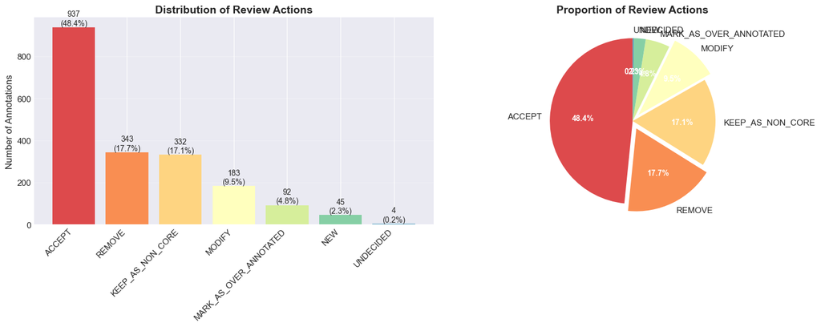

```
📊 Action Summary:
  • Accepted as-is: 937 (48.4%)
  • Modifications needed: 183 (9.5%)
  • Removed: 343 (17.7%)
```

```python
# Create figure with two subplots
fig, (ax1, ax2) = plt.subplots(1, 2, figsize=(16, 6))

# Count of review actions
action_counts = df['review_action'].value_counts()
colors = sns.color_palette("Spectral", len(action_counts))

# Bar chart
bars = ax1.bar(range(len(action_counts)), action_counts.values, color=colors)
ax1.set_xticks(range(len(action_counts)))
ax1.set_xticklabels(action_counts.index, rotation=45, ha='right')
ax1.set_ylabel('Number of Annotations')
ax1.set_title('Distribution of Review Actions', fontweight='bold', fontsize=14)
ax1.grid(axis='y', alpha=0.3)

# Add value labels on bars
for bar, value in zip(bars, action_counts.values):
    height = bar.get_height()
    ax1.text(bar.get_x() + bar.get_width()/2., height + 1,
             f'{int(value)}\n({value/len(df)*100:.1f}%)',
             ha='center', va='bottom', fontsize=10)

# Pie chart with exploded slices for important actions
explode = [0.1 if action in ['MODIFY', 'REMOVE'] else 0 for action in action_counts.index]
wedges, texts, autotexts = ax2.pie(action_counts.values,
                                     labels=action_counts.index,
                                     colors=colors,
                                     autopct='%1.1f%%',
                                     explode=explode,
                                     startangle=90)
ax2.set_title('Proportion of Review Actions', fontweight='bold', fontsize=14)

# Make percentage text bold
for autotext in autotexts:
    autotext.set_color('white')
    autotext.set_fontweight('bold')
    autotext.set_fontsize(10)

plt.tight_layout()
plt.show()

# Summary statistics
print("\n📊 Action Summary:")
print(f"  • Accepted as-is: {action_counts.get('ACCEPT', 0)} ({action_counts.get('ACCEPT', 0)/len(df)*100:.1f}%)")
print(f"  • Modifications needed: {action_counts.get('MODIFY', 0)} ({action_counts.get('MODIFY', 0)/len(df)*100:.1f}%)")
print(f"  • Removed: {action_counts.get('REMOVE', 0)} ({action_counts.get('REMOVE', 0)/len(df)*100:.1f}%)")
```

## 🧬 Species-Specific Analysis

### What This Shows

Compares annotation quality across different organisms. Some species may have better-curated annotations due to their model organism status or research focus. The stacked bar chart shows relative proportions while the heatmap shows absolute counts.

### How It's Calculated

- Groups annotations by species (taxon)
- Calculates the distribution of review actions within each species
- Normalizes to percentages for fair comparison across species with different annotation counts
- Filters to top 10 species by annotation volume for clarity

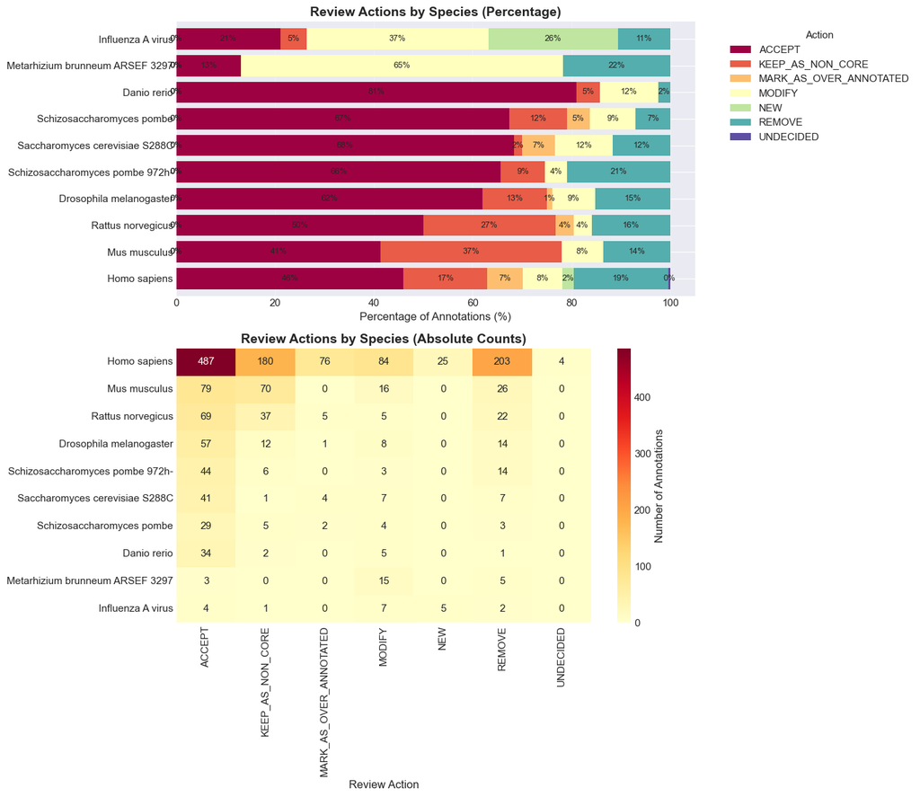

```python
# Prepare species data
species_action = pd.crosstab(df['taxon_label'], df['review_action'], normalize='index') * 100
species_counts = df['taxon_label'].value_counts()

# Filter to top species by annotation count
top_species = species_counts.head(10).index
species_action_filtered = species_action.loc[top_species]

# Create stacked bar chart
fig, (ax1, ax2) = plt.subplots(2, 1, figsize=(14, 12))

# Stacked percentage bar chart
species_action_filtered.plot(kind='barh', stacked=True, ax=ax1,
                             colormap='Spectral', width=0.8)
ax1.set_xlabel('Percentage of Annotations (%)')
ax1.set_ylabel('')
ax1.set_title('Review Actions by Species (Percentage)', fontweight='bold', fontsize=14)
ax1.legend(title='Action', bbox_to_anchor=(1.05, 1), loc='upper left')
ax1.grid(axis='x', alpha=0.3)

# Add percentage labels
for container in ax1.containers:
    ax1.bar_label(container, fmt='%.0f%%', label_type='center', fontsize=9)

# Absolute counts heatmap
species_action_abs = pd.crosstab(df['taxon_label'], df['review_action'])
species_action_abs_filtered = species_action_abs.loc[top_species]

sns.heatmap(species_action_abs_filtered, annot=True, fmt='d', cmap='YlOrRd',
            ax=ax2, cbar_kws={'label': 'Number of Annotations'})
ax2.set_ylabel('')
ax2.set_xlabel('Review Action')
ax2.set_title('Review Actions by Species (Absolute Counts)', fontweight='bold', fontsize=14)

plt.tight_layout()
plt.show()
```

## 🔬 Evidence Type Analysis

### What This Shows

Analyzes annotation quality based on the type of evidence supporting each annotation. Evidence types range from experimental (IDA, IMP) to computational (IEA, ISS). This helps identify which evidence sources are most reliable.

### Key Evidence Types

- **IDA/IMP/IPI**: Direct experimental evidence (highest quality)
- **ISS/ISO/ISA**: Sequence similarity-based (moderate quality)
- **IEA**: Electronic annotation (lowest quality, no manual review)
- **TAS/IC**: Traceable author statement or curator inference

### How It's Calculated

- Groups annotations by evidence code
- Calculates acceptance rates and action distributions for each evidence type
- Identifies evidence types with highest/lowest quality

[figure not shown]

```
📊 Method Analysis Summary:
============================================================

Method                Count   Accept  Accept%   Remove  Remove%  NonCore
---------------------------------------------------------------------------
Experimental            802      363    45.3%      166    20.7%      221
ARBA                    319      128    40.1%       55    17.2%      108
UniProtKB-KW            164       54    32.9%       45    27.4%       23
Combined-IEA            143       94    65.7%       20    14.0%       10
IBA                     107       83    77.6%        4     3.7%        9
InterPro2GO              84       39    46.4%       14    16.7%       12
TAS                      79       61    77.2%       11    13.9%        2
ISS                      64       24    37.5%        3     4.7%       11
ISO                      60       26    43.3%        7    11.7%       21
UniProtKB-SubCell        27       21    77.8%        2     7.4%        2
EXP                      20       13    65.0%        3    15.0%        0
NAS                      16       12    75.0%        1     6.2%        1
IC                       11        1     9.1%        0     0.0%        0
Ensembl                  11        3    27.3%        2    18.2%        3
ND                        6        1    16.7%        5    83.3%        0
EC2GO                     6        6   100.0%        0     0.0%        0
UniRule                   5        2    40.0%        1    20.0%        0
TreeGrafter               4        0     0.0%        3    75.0%        1
RHEA                      3        2    66.7%        1    33.3%        0
ISA                       2        2   100.0%        0     0.0%        0
IEA-Other                 2        1    50.0%        0     0.0%        0
ISM                       1        1   100.0%        0     0.0%        0

📈 Key Insights:
  • Total methods: 22
  • Most common: Experimental (802 annotations, 41.4%)

🔍 ARBA Analysis:
  • Total: 319 annotations
  • Accepted: 128 (40.1%)
  • Removed: 55 (17.2%)
  • Non-Core/Over-Annotated: 108
```

```python
# Method analysis (combining evidence type and reference source)
# This provides a higher-level view than raw evidence codes
if 'method' in df.columns:
    method_counts = df['method'].value_counts()

    # Create action categories if not already present
    if 'action_category' not in df.columns:
        def categorize_action(action):
            if action == 'ACCEPT':
                return 'Accept'
            elif action == 'MODIFY':
                return 'Modify'
            elif action == 'REMOVE':
                return 'Remove'
            elif action in ['KEEP_AS_NON_CORE', 'MARK_AS_OVER_ANNOTATED']:
                return 'Non-Core/Over-Annotated'
            else:
                return 'Other'
        df['action_category'] = df['review_action'].apply(categorize_action)

    fig, axes = plt.subplots(2, 2, figsize=(18, 12))

    # 1. Method vs Review Action heatmap - COUNTS
    method_action = pd.crosstab(df['method'], df['review_action'])

    sns.heatmap(method_action, annot=True, fmt='d', cmap='YlOrRd', ax=axes[0, 0],
                cbar_kws={'label': 'Count'})
    axes[0, 0].set_title('Review Actions by Method (Counts)', fontweight='bold', fontsize=12)
    axes[0, 0].set_xlabel('Review Action')
    axes[0, 0].set_ylabel('Method')
    axes[0, 0].tick_params(axis='both', which='major', labelsize=9)

    # 2. Method vs Review Action heatmap - PERCENTAGES
    method_action_pct = pd.crosstab(df['method'], df['review_action'], normalize='index') * 100

    sns.heatmap(method_action_pct, annot=True, fmt='.0f', cmap='RdYlGn_r', ax=axes[0, 1],
                cbar_kws={'label': 'Percentage (%)'}, vmin=0, vmax=50)
    axes[0, 1].set_title('Review Actions by Method (Row %)', fontweight='bold', fontsize=12)
    axes[0, 1].set_xlabel('Review Action')
    axes[0, 1].set_ylabel('')
    axes[0, 1].tick_params(axis='both', which='major', labelsize=9)

    # 3. ACTION RATES BY METHOD - STACKED BAR CHART
    # Calculate percentages for each method
    method_action_rates = pd.crosstab(df['method'], df['action_category'], normalize='index') * 100

    # Order columns for stacking
    action_order = ['Accept', 'Modify', 'Remove', 'Non-Core/Over-Annotated', 'Other']
    existing_cols = [col for col in action_order if col in method_action_rates.columns]
    method_action_rates = method_action_rates[existing_cols]

    # Sort by total annotations (most common first)
    method_action_rates = method_action_rates.loc[method_counts.index]

    # Create stacked bar chart
    x = np.arange(len(method_action_rates))
    width = 0.7

    # Define colors for each action category
    action_colors = {
        'Accept': 'green',
        'Modify': 'orange',
        'Remove': 'red',
        'Non-Core/Over-Annotated': 'purple',
        'Other': 'gray'
    }

    # Plot stacked bars
    bottom = np.zeros(len(method_action_rates))
    for action in existing_cols:
        values = method_action_rates[action].values
        color = action_colors.get(action, 'gray')
        axes[1, 0].bar(x, values, width, bottom=bottom, label=action, color=color, alpha=0.8)
        bottom += values

    axes[1, 0].set_xticks(x)
    axes[1, 0].set_xticklabels(method_action_rates.index, rotation=45, ha='right', fontsize=9)
    axes[1, 0].set_ylabel('Percentage (%)')
    axes[1, 0].set_title('Action Rates by Method', fontweight='bold', fontsize=12)
    axes[1, 0].legend(loc='upper right')
    axes[1, 0].grid(axis='y', alpha=0.3)
    axes[1, 0].set_ylim(0, 100)

    # Add sample sizes above bars
    for i, method in enumerate(method_action_rates.index):
        count = method_counts[method]
        axes[1, 0].text(i, 102, f'n={count}', ha='center', fontsize=8, color='black')

    # 4. Method distribution bar chart
    colors_dist = sns.color_palette("viridis", len(method_counts))
    bars = axes[1, 1].bar(range(len(method_counts)), method_counts.values, color=colors_dist)
    axes[1, 1].set_xticks(range(len(method_counts)))
    axes[1, 1].set_xticklabels(method_counts.index, rotation=45, ha='right', fontsize=9)
    axes[1, 1].set_ylabel('Number of Annotations')
    axes[1, 1].set_title('Distribution of Methods', fontweight='bold', fontsize=12)
    axes[1, 1].grid(axis='y', alpha=0.3)

    # Add count labels
    for bar, value in zip(bars, method_counts.values):
        height = bar.get_height()
        axes[1, 1].text(bar.get_x() + bar.get_width()/2., height + 5,
                        f'{int(value)}', ha='center', va='bottom', fontsize=9)

    plt.suptitle('Method Analysis Overview', fontsize=14, fontweight='bold', y=1.02)
    plt.tight_layout()
    plt.show()

    # Print detailed summary
    print("\n📊 Method Analysis Summary:")
    print("=" * 60)

    # Create summary DataFrame
    method_summary = pd.DataFrame({
        'Count': df.groupby('method').size(),
        'Accepted': df[df['review_action'] == 'ACCEPT'].groupby('method').size().reindex(df['method'].unique(), fill_value=0),
        'Accept_Rate': df.groupby('method')['review_action'].apply(lambda x: (x == 'ACCEPT').mean() * 100),
        'Removed': df[df['review_action'] == 'REMOVE'].groupby('method').size().reindex(df['method'].unique(), fill_value=0),
        'Remove_Rate': df.groupby('method')['review_action'].apply(lambda x: (x == 'REMOVE').mean() * 100),
        'Non-Core/Over': df[df['review_action'].isin(['KEEP_AS_NON_CORE', 'MARK_AS_OVER_ANNOTATED'])].groupby('method').size().reindex(df['method'].unique(), fill_value=0),
    }).sort_values('Count', ascending=False)

    print(f"\n{'Method':<20} {'Count':>6} {'Accept':>8} {'Accept%':>8} {'Remove':>8} {'Remove%':>8} {'NonCore':>8}")
    print("-" * 75)
    for method, row in method_summary.iterrows():
        print(f"{method:<20} {int(row['Count']):6d} {int(row['Accepted']):8d} {row['Accept_Rate']:7.1f}% {int(row['Removed']):8d} {row['Remove_Rate']:7.1f}% {int(row['Non-Core/Over']):8d}")

    print("\n📈 Key Insights:")
    print(f"  • Total methods: {df['method'].nunique()}")
    print(f"  • Most common: {method_counts.index[0]} ({method_counts.iloc[0]} annotations, {method_counts.iloc[0]/len(df)*100:.1f}%)")

    # Report on ARBA specifically
    if 'ARBA' in method_summary.index:
        arba_row = method_summary.loc['ARBA']
        print(f"\n🔍 ARBA Analysis:")
        print(f"  • Total: {int(arba_row['Count'])} annotations")
        print(f"  • Accepted: {int(arba_row['Accepted'])} ({arba_row['Accept_Rate']:.1f}%)")
        print(f"  • Removed: {int(arba_row['Removed'])} ({arba_row['Remove_Rate']:.1f}%)")
        print(f"  • Non-Core/Over-Annotated: {int(arba_row['Non-Core/Over'])}")
else:
    print("⚠️ Method column not found in data. Please re-export annotations to include the new method field.")
```

## 🧪 Method Analysis (Evidence + Reference)

### What This Shows

The 'Method' field consolidates evidence type with reference source, providing a higher-level view of annotation provenance. For example, 'ARBA' represents automated annotations from UniProt rules, while 'Experimental' groups all experimental evidence types together.

### Why This Matters

- **Method** gives context about HOW and WHERE annotations originated
- Helps identify systematic biases from specific annotation pipelines
- Shows which automated methods (ARBA, InterPro2GO, etc.) produce reliable annotations

### How It's Calculated

- Combines evidence codes with reference database information
- Groups similar evidence types (all experimental codes → 'Experimental')
- Preserves source information for automated annotations

[figure not shown]

```python
# Evidence type distribution with action rates
evidence_counts = df['evidence_type'].value_counts()

fig, axes = plt.subplots(2, 2, figsize=(16, 12))

# 1. Overall evidence type distribution
colors = sns.color_palette("viridis", len(evidence_counts))
bars = axes[0, 0].bar(range(len(evidence_counts)), evidence_counts.values, color=colors)
axes[0, 0].set_xticks(range(len(evidence_counts)))
axes[0, 0].set_xticklabels(evidence_counts.index, rotation=45, ha='right')
axes[0, 0].set_ylabel('Number of Annotations')
axes[0, 0].set_title('Distribution of Evidence Types', fontweight='bold')
axes[0, 0].grid(axis='y', alpha=0.3)

# Add count labels
for bar, value in zip(bars, evidence_counts.values):
    height = bar.get_height()
    axes[0, 0].text(bar.get_x() + bar.get_width()/2., height + 1,
                    f'{int(value)}', ha='center', va='bottom')

# 2. Evidence type vs Review action heatmap
evidence_action = pd.crosstab(df['evidence_type'], df['review_action'])
sns.heatmap(evidence_action, annot=True, fmt='d', cmap='coolwarm', ax=axes[0, 1],
            cbar_kws={'label': 'Count'})
axes[0, 1].set_title('Evidence Type vs Review Action', fontweight='bold')
axes[0, 1].set_xlabel('Review Action')
axes[0, 1].set_ylabel('Evidence Type')

# 3. Acceptance rate by evidence type
evidence_accept_rate = pd.crosstab(df['evidence_type'],
                                   df['review_action'] == 'ACCEPT',
                                   normalize='index')[True] * 100
evidence_accept_rate = evidence_accept_rate.sort_values(ascending=False)

bars = axes[1, 0].barh(range(len(evidence_accept_rate)),
                       evidence_accept_rate.values,
                       color=sns.color_palette("RdYlGn", len(evidence_accept_rate))[::-1])
axes[1, 0].set_yticks(range(len(evidence_accept_rate)))
axes[1, 0].set_yticklabels(evidence_accept_rate.index)
axes[1, 0].set_xlabel('Acceptance Rate (%)')
axes[1, 0].set_title('Acceptance Rate by Evidence Type', fontweight='bold')
axes[1, 0].grid(axis='x', alpha=0.3)

# Add percentage labels
for bar, value in zip(bars, evidence_accept_rate.values):
    width = bar.get_width()
    axes[1, 0].text(width + 1, bar.get_y() + bar.get_height()/2.,
                    f'{value:.1f}%', ha='left', va='center')

# 4. ACTION RATES BY EVIDENCE TYPE - STACKED BAR CHART
# Group actions into categories
def categorize_action(action):
    if action == 'ACCEPT':
        return 'Accept'
    elif action == 'MODIFY':
        return 'Modify'
    elif action == 'REMOVE':
        return 'Remove'
    elif action in ['KEEP_AS_NON_CORE', 'MARK_AS_OVER_ANNOTATED']:
        return 'Non-Core/Over-Annotated'
    else:
        return 'Other'

df['action_category'] = df['review_action'].apply(categorize_action)

# Calculate percentages for each evidence type
evidence_action_rates = pd.crosstab(df['evidence_type'], df['action_category'], normalize='index') * 100

# Order columns for stacking
action_order = ['Accept', 'Modify', 'Remove', 'Non-Core/Over-Annotated', 'Other']
existing_cols = [col for col in action_order if col in evidence_action_rates.columns]
evidence_action_rates = evidence_action_rates[existing_cols]

# Sort by total annotations (most common first)
evidence_action_rates = evidence_action_rates.loc[evidence_counts.index]

# Create stacked bar chart
x = np.arange(len(evidence_action_rates))
width = 0.6

# Define colors for each action category
action_colors = {
    'Accept': 'green',
    'Modify': 'orange',
    'Remove': 'red',
    'Non-Core/Over-Annotated': 'purple',
    'Other': 'gray'
}

# Plot stacked bars
bottom = np.zeros(len(evidence_action_rates))
for action in existing_cols:
    values = evidence_action_rates[action].values
    color = action_colors.get(action, 'gray')
    axes[1, 1].bar(x, values, width, bottom=bottom, label=action, color=color, alpha=0.8)
    bottom += values

axes[1, 1].set_xticks(x)
axes[1, 1].set_xticklabels(evidence_action_rates.index, rotation=45, ha='right')
axes[1, 1].set_ylabel('Percentage (%)')
axes[1, 1].set_title('Action Rates by Evidence Type', fontweight='bold')
axes[1, 1].legend(loc='upper right')
axes[1, 1].grid(axis='y', alpha=0.3)
axes[1, 1].set_ylim(0, 100)

plt.tight_layout()
plt.show()
```

[figure not shown]

```
🔍 Method vs Evidence Detailed Comparison:
============================================================

📊 Consolidation Impact:
  • 802 experimental evidence codes → 1 'Experimental' method
  • 768 IEA annotations → 11 distinct methods

📈 Quality Indicators:
  • Experimental acceptance rate: 45.3%
  • Automated acceptance rate: 44.4%
  • Difference: +0.9 percentage points
```

```python
# Compare Method (consolidated) vs Evidence (raw) views
if 'method' in df.columns:
    fig = plt.figure(figsize=(18, 12))
    gs = fig.add_gridspec(3, 3, hspace=0.3, wspace=0.3)

    # 1. Side-by-side pie charts: Method vs Evidence
    ax1 = fig.add_subplot(gs[0, 0])
    method_top = df['method'].value_counts().head(8)
    colors1 = sns.color_palette("Set2", len(method_top))
    wedges, texts, autotexts = ax1.pie(method_top.values, labels=method_top.index,
                                        autopct='%1.1f%%', colors=colors1, startangle=90)
    ax1.set_title('Top Methods (Consolidated)', fontweight='bold')
    for autotext in autotexts:
        autotext.set_color('white')
        autotext.set_fontweight('bold')
        autotext.set_fontsize(9)

    ax2 = fig.add_subplot(gs[0, 1])
    evidence_top = df['evidence_type'].value_counts().head(8)
    colors2 = sns.color_palette("Set3", len(evidence_top))
    wedges, texts, autotexts = ax2.pie(evidence_top.values, labels=evidence_top.index,
                                       autopct='%1.1f%%', colors=colors2, startangle=90)
    ax2.set_title('Top Evidence Types (Raw)', fontweight='bold')
    for autotext in autotexts:
        autotext.set_color('black')
        autotext.set_fontweight('bold')
        autotext.set_fontsize(9)

    # 2. Acceptance rates comparison
    ax3 = fig.add_subplot(gs[0, 2])

    # Calculate acceptance rates for methods
    method_accept = df.groupby('method')['review_action'].apply(
        lambda x: (x == 'ACCEPT').mean() * 100
    ).sort_values(ascending=False).head(10)

    # Calculate acceptance rates for evidence
    evidence_accept = df.groupby('evidence_type')['review_action'].apply(
        lambda x: (x == 'ACCEPT').mean() * 100
    ).sort_values(ascending=False).head(10)

    x = np.arange(10)
    width = 0.35

    bars1 = ax3.barh(x - width/2, method_accept.values[:10], width,
                     label='By Method', color='steelblue', alpha=0.8)
    bars2 = ax3.barh(x + width/2, evidence_accept.values[:10], width,
                     label='By Evidence', color='coral', alpha=0.8)

    ax3.set_yticks(x)
    ax3.set_yticklabels([f"{i+1}" for i in range(10)])
    ax3.set_xlabel('Acceptance Rate (%)')
    ax3.set_title('Top 10 Acceptance Rates Comparison', fontweight='bold')
    ax3.legend()
    ax3.grid(axis='x', alpha=0.3)

    # 3. Method breakdown for IEA annotations
    ax4 = fig.add_subplot(gs[1, :])
    iea_methods = df[df['evidence_type'] == 'IEA']['method'].value_counts()

    bars = ax4.bar(range(len(iea_methods)), iea_methods.values,
                   color=sns.color_palette("viridis", len(iea_methods)))
    ax4.set_xticks(range(len(iea_methods)))
    ax4.set_xticklabels(iea_methods.index, rotation=45, ha='right')
    ax4.set_ylabel('Number of Annotations')
    ax4.set_title('IEA Annotations Breakdown by Method/Source', fontweight='bold', fontsize=14)
    ax4.grid(axis='y', alpha=0.3)

    # Add value and percentage labels
    for bar, (method, count) in zip(bars, iea_methods.items()):
        height = bar.get_height()
        pct = count / df[df['evidence_type'] == 'IEA'].shape[0] * 100
        ax4.text(bar.get_x() + bar.get_width()/2., height + 2,
                f'{int(count)}\n({pct:.1f}%)', ha='center', va='bottom', fontsize=9)

    # 4. Sankey-style flow from Evidence to Method
    ax5 = fig.add_subplot(gs[2, :2])

    # Create crosstab of evidence to method mapping
    evidence_method = pd.crosstab(df['evidence_type'], df['method'])

    # Filter to most common combinations
    top_evidence = df['evidence_type'].value_counts().head(8).index
    top_methods = df['method'].value_counts().head(8).index
    evidence_method_filtered = evidence_method.loc[
        evidence_method.index.intersection(top_evidence),
        evidence_method.columns.intersection(top_methods)
    ]

    sns.heatmap(evidence_method_filtered, annot=True, fmt='d', cmap='YlGnBu',
                ax=ax5, cbar_kws={'label': 'Count'})
    ax5.set_title('Evidence Type to Method Mapping', fontweight='bold', fontsize=12)
    ax5.set_xlabel('Method (Consolidated)')
    ax5.set_ylabel('Evidence Type (Raw)')

    # 5. Summary statistics table
    ax6 = fig.add_subplot(gs[2, 2])
    ax6.axis('tight')
    ax6.axis('off')

    # Calculate statistics
    method_stats = {
        'Unique Methods': df['method'].nunique(),
        'Unique Evidence Types': df['evidence_type'].nunique(),
        'Most Common Method': f"{method_counts.index[0]} ({method_counts.iloc[0]})",
        'Most Common Evidence': f"{evidence_counts.index[0]} ({evidence_counts.iloc[0]})",
        'IEA Breakdown': f"{df[df['evidence_type'] == 'IEA']['method'].nunique()} sources",
        'Experimental %': f"{(df['method'] == 'Experimental').mean() * 100:.1f}%"
    }

    table_data = [[k, str(v)] for k, v in method_stats.items()]
    table = ax6.table(cellText=table_data, cellLoc='left', loc='center',
                     colWidths=[0.6, 0.4])
    table.auto_set_font_size(False)
    table.set_fontsize(10)
    table.scale(1.2, 1.8)

    # Style the table
    for i in range(len(table_data)):
        table[(i, 0)].set_facecolor('#E8F4F8')
        table[(i, 0)].set_text_props(weight='bold')

    ax6.set_title('Comparison Summary', fontweight='bold', fontsize=12)

    plt.suptitle('Method vs Evidence Type Analysis', fontsize=16, fontweight='bold', y=0.98)
    plt.tight_layout()
    plt.show()

    # Print detailed comparison
    print("\n🔍 Method vs Evidence Detailed Comparison:")
    print("=" * 60)

    print("\n📊 Consolidation Impact:")
    total_experimental = df[df['evidence_type'].isin(['IDA', 'IPI', 'IMP', 'IGI', 'IEP', 'HTP', 'HDA', 'HMP', 'HGI', 'HEP'])].shape[0]
    print(f"  • {total_experimental} experimental evidence codes → 1 'Experimental' method")

    iea_count = df[df['evidence_type'] == 'IEA'].shape[0]
    iea_methods_count = df[df['evidence_type'] == 'IEA']['method'].nunique()
    print(f"  • {iea_count} IEA annotations → {iea_methods_count} distinct methods")

    print("\n📈 Quality Indicators:")
    exp_accept = df[df['method'] == 'Experimental']['review_action'].eq('ACCEPT').mean() * 100
    auto_accept = df[df['method'].isin(['ARBA', 'UniProtKB-KW', 'Combined-IEA', 'InterPro2GO'])]['review_action'].eq('ACCEPT').mean() * 100
    print(f"  • Experimental acceptance rate: {exp_accept:.1f}%")
    print(f"  • Automated acceptance rate: {auto_accept:.1f}%")
    print(f"  • Difference: {exp_accept - auto_accept:+.1f} percentage points")
else:
    print("⚠️ Method column not found. Please re-export annotations with the updated exporter.")
```

## 🔬📊 Method vs Evidence Comparison

### What This Shows

Compares the consolidated 'Method' view with raw evidence codes to understand how annotation sources affect quality. This reveals patterns like:

- Multiple IEA sources with varying quality
- Experimental evidence consistency across different methods
- Source-specific biases in automated annotations

### Key Insights

- Shows how IEA (electronic) annotations break down by source
- Reveals which automated pipelines are most trustworthy
- Identifies discrepancies between evidence type and actual quality

[figure not shown]

```
🌊 Flow Analysis Summary:
============================================================
Total unique flows: 39
Total annotations in flows ≥5: 1871
Most common flow: Experimental → Accept (363 annotations)

📊 Overall Action Distribution (from flows ≥5):
  • Accept: 924 (49.4%)
  • Non-Core/Over-Annotated: 415 (22.2%)
  • Remove: 323 (17.3%)
  • Modify: 166 (8.9%)
  • Other: 43 (2.3%)
```

```python
# Sankey diagram for Method -> Action flow
try:
    import plotly.graph_objects as go
    import plotly.offline as pyo

    # Prepare data for Sankey diagram
    if 'method' in df.columns:
        # Create the flow data
        flow_data = df.groupby(['method', 'action_category']).size().reset_index(name='count')

        # Filter to significant flows (at least 5 annotations) for clarity
        flow_data = flow_data[flow_data['count'] >= 5]

        # Create node lists
        methods = flow_data['method'].unique().tolist()
        actions = flow_data['action_category'].unique().tolist()

        # All nodes (methods + actions)
        all_nodes = methods + actions
        node_indices = {node: i for i, node in enumerate(all_nodes)}

        # Create source, target, and value lists for Sankey
        source = [node_indices[method] for method in flow_data['method']]
        target = [node_indices[action] for action in flow_data['action_category']]
        value = flow_data['count'].tolist()

        # Define colors
        method_colors = ['lightblue'] * len(methods)
        action_color_map = {
            'Accept': 'green',
            'Modify': 'orange',
            'Remove': 'red',
            'Non-Core/Over-Annotated': 'purple',
            'Other': 'gray'
        }
        action_colors = [action_color_map.get(action, 'gray') for action in actions]
        node_colors = method_colors + action_colors

        # Create Sankey diagram
        fig = go.Figure(data=[go.Sankey(
            node=dict(
                pad=15,
                thickness=20,
                line=dict(color="black", width=0.5),
                label=all_nodes,
                color=node_colors,
                hovertemplate='%{label}<br>Total: %{value}<extra></extra>'
            ),
            link=dict(
                source=source,
                target=target,
                value=value,
                color='rgba(200, 200, 200, 0.4)',
                hovertemplate='%{source.label} → %{target.label}<br>Count: %{value}<extra></extra>'
            )
        )])

        fig.update_layout(
            title_text="Method to Action Flow (flows ≥5 annotations)",
            font_size=12,
            height=600,
            margin=dict(l=50, r=50, t=50, b=50)
        )

        # Display the figure
        pyo.iplot(fig)

        # Also create a static version using matplotlib
        fig2, (ax1, ax2) = plt.subplots(1, 2, figsize=(18, 8))

        # 1. Top flows table
        top_flows = flow_data.nlargest(20, 'count')
        top_flows['percentage'] = (top_flows['count'] / top_flows['count'].sum() * 100).round(1)

        # Format for display
        table_data = []
        table_data.append(['Method', 'Action', 'Count', '%'])
        table_data.append(['─' * 20, '─' * 25, '─' * 8, '─' * 8])

        for _, row in top_flows.iterrows():
            table_data.append([
                row['method'][:20],
                row['action_category'][:25],
                f"{int(row['count']):4d}",
                f"{row['percentage']:5.1f}%"
            ])

        ax1.axis('tight')
        ax1.axis('off')
        table = ax1.table(cellText=table_data, cellLoc='left', loc='center',
                         colWidths=[0.3, 0.35, 0.15, 0.15])
        table.auto_set_font_size(False)
        table.set_fontsize(9)
        table.scale(1.2, 1.2)

        # Style header
        for i in range(4):
            table[(0, i)].set_facecolor('#4CAF50')
            table[(0, i)].set_text_props(weight='bold', color='white')

        ax1.set_title('Top 20 Method→Action Flows', fontweight='bold', fontsize=12)

        # 2. Summary by method
        method_flow_summary = flow_data.pivot_table(
            index='method',
            columns='action_category',
            values='count',
            aggfunc='sum',
            fill_value=0
        )

        # Sort by total flow
        method_flow_summary['Total'] = method_flow_summary.sum(axis=1)
        method_flow_summary = method_flow_summary.sort_values('Total', ascending=False).head(10)

        # Create stacked bar chart
        categories = [col for col in method_flow_summary.columns if col != 'Total']
        x = np.arange(len(method_flow_summary))

        bottom = np.zeros(len(method_flow_summary))
        for category in categories:
            if category in method_flow_summary.columns:
                values = method_flow_summary[category].values
                color = action_color_map.get(category, 'gray')
                ax2.barh(x, values, left=bottom, label=category, color=color, alpha=0.8)
                bottom += values

        ax2.set_yticks(x)
        ax2.set_yticklabels(method_flow_summary.index, fontsize=10)
        ax2.set_xlabel('Number of Annotations')
        ax2.set_title('Top 10 Methods: Action Distribution', fontweight='bold', fontsize=12)
        ax2.legend(loc='lower right')
        ax2.grid(axis='x', alpha=0.3)

        # Add totals at the end of bars
        for i, total in enumerate(method_flow_summary['Total']):
            ax2.text(total + 5, i, f'{int(total)}', va='center', fontsize=9)

        plt.suptitle('Method to Action Flow Analysis', fontsize=14, fontweight='bold', y=1.02)
        plt.tight_layout()
        plt.show()

        # Print flow statistics
        print("\n🌊 Flow Analysis Summary:")
        print("=" * 60)
        print(f"Total unique flows: {len(flow_data)}")
        print(f"Total annotations in flows ≥5: {flow_data['count'].sum()}")
        print(f"Most common flow: {top_flows.iloc[0]['method']} → {top_flows.iloc[0]['action_category']} ({top_flows.iloc[0]['count']} annotations)")

        # Calculate percentage of each action across all methods
        action_totals = flow_data.groupby('action_category')['count'].sum()
        print("\n📊 Overall Action Distribution (from flows ≥5):")
        for action, count in action_totals.sort_values(ascending=False).items():
            pct = count / action_totals.sum() * 100
            print(f"  • {action}: {count} ({pct:.1f}%)")

except ImportError:
    print("⚠️ Plotly not installed. Installing it will enable interactive Sankey diagrams.")
    print("   To install: uv add plotly")

    # Fallback visualization without Plotly
    if 'method' in df.columns:
        fig, ax = plt.subplots(figsize=(14, 10))

        # Create flow matrix
        flow_matrix = pd.crosstab(df['method'], df['action_category'])

        # Filter to top methods for readability
        top_methods = df['method'].value_counts().head(15).index
        flow_matrix_filtered = flow_matrix.loc[top_methods]

        # Create heatmap as fallback
        sns.heatmap(flow_matrix_filtered, annot=True, fmt='d', cmap='YlGnBu',
                    cbar_kws={'label': 'Count'}, ax=ax)
        ax.set_title('Method to Action Flow Matrix (Top 15 Methods)', fontweight='bold', fontsize=14)
        ax.set_xlabel('Action Category', fontsize=12)
        ax.set_ylabel('Method', fontsize=12)

        plt.tight_layout()
        plt.show()

        print("\n📊 Method→Action Flow Summary (Top 15 Methods):")
        for method in top_methods[:5]:
            flows = flow_matrix.loc[method]
            flows = flows[flows > 0].sort_values(ascending=False)
            print(f"\n{method}:")
            for action, count in flows.items():
                pct = count / flows.sum() * 100
                print(f"  → {action}: {count} ({pct:.1f}%)")
```

## 🌊 Method to Action Flow Analysis

### How to Read This

- Width of flows represents number of annotations
- Color coding shows action types (green=accept, red=remove, etc.)
- Helps identify which sources consistently produce good/bad annotations

### How It's Calculated

- Creates source→action pairs for each annotation
- Aggregates flows and filters to significant patterns (≥5 annotations)
- Visualizes as either interactive Sankey or static heatmap

## 🎯 GO Term Ontology Analysis

### What This Shows

Analyzes patterns across the three GO ontologies:

- **Molecular Function (MF)**: What the protein does at molecular level
- **Biological Process (BP)**: Larger biological goals the protein contributes to
- **Cellular Component (CC)**: Where in the cell the protein acts

### How It's Calculated

- Classifies each annotation by its GO ontology branch
- Identifies frequently annotated terms and their quality
- Finds terms with high modification rates (indicating systematic issues)

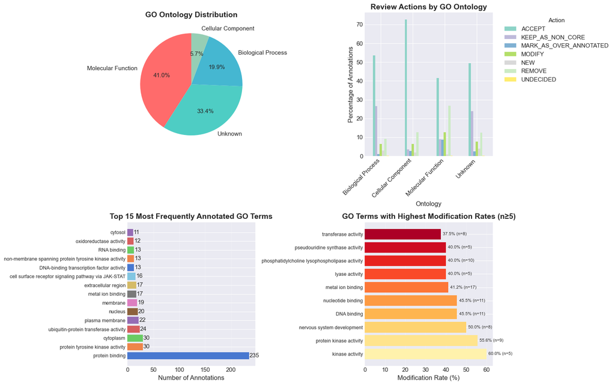

```python
# Extract ontology from term_id (GO:XXXXXXX)
# Determine ontology based on term_ontology column or infer from common patterns
def get_ontology(row):
    if pd.notna(row['term_ontology']):
        return row['term_ontology']
    # Infer from term label patterns
    term = str(row['term_label']).lower()
    if 'binding' in term or 'activity' in term or 'transporter' in term:
        return 'Molecular Function'
    elif 'process' in term or 'regulation' in term or 'pathway' in term:
        return 'Biological Process'
    elif 'complex' in term or 'membrane' in term or 'region' in term:
        return 'Cellular Component'
    return 'Unknown'

df['ontology'] = df.apply(get_ontology, axis=1)

fig, axes = plt.subplots(2, 2, figsize=(16, 10))

# 1. Distribution across ontologies
ontology_counts = df['ontology'].value_counts()
colors = ['#FF6B6B', '#4ECDC4', '#45B7D1', '#96CEB4']
wedges, texts, autotexts = axes[0, 0].pie(ontology_counts.values,
                                           labels=ontology_counts.index,
                                           colors=colors[:len(ontology_counts)],
                                           autopct='%1.1f%%',
                                           startangle=90)
axes[0, 0].set_title('GO Ontology Distribution', fontweight='bold')

# 2. Review actions by ontology
ontology_action = pd.crosstab(df['ontology'], df['review_action'], normalize='index') * 100
ontology_action.plot(kind='bar', ax=axes[0, 1], colormap='Set3')
axes[0, 1].set_xlabel('Ontology')
axes[0, 1].set_ylabel('Percentage of Annotations')
axes[0, 1].set_title('Review Actions by GO Ontology', fontweight='bold')
axes[0, 1].legend(title='Action', bbox_to_anchor=(1.05, 1), loc='upper left')
axes[0, 1].set_xticklabels(axes[0, 1].get_xticklabels(), rotation=45, ha='right')

# 3. Most frequently reviewed terms
top_terms = df['term_label'].value_counts().head(15)
axes[1, 0].barh(range(len(top_terms)), top_terms.values,
               color=sns.color_palette("muted", len(top_terms)))
axes[1, 0].set_yticks(range(len(top_terms)))
axes[1, 0].set_yticklabels(top_terms.index, fontsize=9)
axes[1, 0].set_xlabel('Number of Annotations')
axes[1, 0].set_title('Top 15 Most Frequently Annotated GO Terms', fontweight='bold')
axes[1, 0].grid(axis='x', alpha=0.3)

# Add count labels
for i, value in enumerate(top_terms.values):
    axes[1, 0].text(value + 0.5, i, str(value), va='center')

# 4. Terms with highest modification rates
term_stats = df.groupby('term_label').agg({
    'review_action': ['count', lambda x: (x == 'MODIFY').mean() * 100]
}).reset_index()
term_stats.columns = ['term', 'count', 'modify_rate']
term_stats = term_stats[term_stats['count'] >= 5]  # Filter for terms with at least 5 annotations
term_stats = term_stats.nlargest(10, 'modify_rate')

axes[1, 1].barh(range(len(term_stats)), term_stats['modify_rate'].values,
               color=sns.color_palette("YlOrRd", len(term_stats)))
axes[1, 1].set_yticks(range(len(term_stats)))
axes[1, 1].set_yticklabels(term_stats['term'].values, fontsize=9)
axes[1, 1].set_xlabel('Modification Rate (%)')
axes[1, 1].set_title('GO Terms with Highest Modification Rates (n≥5)', fontweight='bold')
axes[1, 1].grid(axis='x', alpha=0.3)

# Add percentage labels
for i, (rate, count) in enumerate(zip(term_stats['modify_rate'].values, term_stats['count'].values)):
    axes[1, 1].text(rate + 1, i, f'{rate:.1f}% (n={int(count)})', va='center', fontsize=8)

plt.tight_layout()
plt.show()
```

## 📊 Gene-Level Statistics

### What This Shows

Aggregates annotations at the gene level to identify:

- Genes that are over-annotated (too many GO terms)
- Genes with consistently poor annotation quality
- Correlation between annotation quantity and quality

### Why This Matters

- Some genes accumulate annotations over time without quality control
- Popular/well-studied genes may have inflated annotation counts
- Helps prioritize which genes need deeper curation

### How It's Calculated

- Groups all annotations by gene symbol
- Calculates per-gene metrics (total annotations, acceptance rate)
- Identifies outliers and patterns

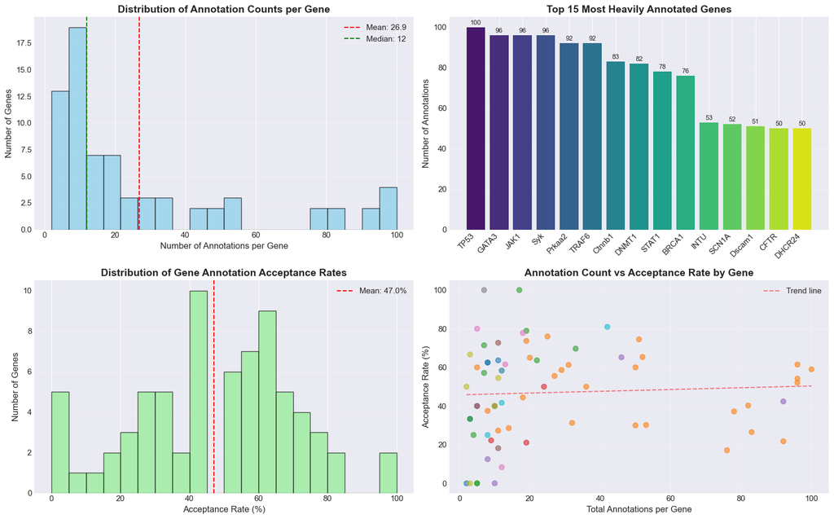

```
📈 Gene-Level Summary:
  • Average annotations per gene: 26.9
  • Median annotations per gene: 12
  • Average acceptance rate: 47.0%
  • Genes with 100% acceptance: 2
  • Genes with 0% acceptance: 5
```

```python
# Gene-level aggregations
gene_stats = df.groupby('gene_symbol').agg({
    'term_id': 'count',
    'review_action': lambda x: (x == 'ACCEPT').sum(),
    'taxon_label': 'first'
}).reset_index()
gene_stats.columns = ['gene', 'total_annotations', 'accepted_annotations', 'species']
gene_stats['acceptance_rate'] = (gene_stats['accepted_annotations'] / gene_stats['total_annotations']) * 100

fig, axes = plt.subplots(2, 2, figsize=(16, 10))

# 1. Distribution of annotations per gene
axes[0, 0].hist(gene_stats['total_annotations'], bins=20, edgecolor='black', alpha=0.7, color='skyblue')
axes[0, 0].set_xlabel('Number of Annotations per Gene')
axes[0, 0].set_ylabel('Number of Genes')
axes[0, 0].set_title('Distribution of Annotation Counts per Gene', fontweight='bold')
axes[0, 0].axvline(gene_stats['total_annotations'].mean(), color='red',
                   linestyle='--', label=f'Mean: {gene_stats["total_annotations"].mean():.1f}')
axes[0, 0].axvline(gene_stats['total_annotations'].median(), color='green',
                   linestyle='--', label=f'Median: {gene_stats["total_annotations"].median():.0f}')
axes[0, 0].legend()
axes[0, 0].grid(axis='y', alpha=0.3)

# 2. Genes with most annotations
top_genes = gene_stats.nlargest(15, 'total_annotations')
bars = axes[0, 1].bar(range(len(top_genes)), top_genes['total_annotations'].values,
                      color=sns.color_palette("viridis", len(top_genes)))
axes[0, 1].set_xticks(range(len(top_genes)))
axes[0, 1].set_xticklabels(top_genes['gene'].values, rotation=45, ha='right')
axes[0, 1].set_ylabel('Number of Annotations')
axes[0, 1].set_title('Top 15 Most Heavily Annotated Genes', fontweight='bold')
axes[0, 1].grid(axis='y', alpha=0.3)

# Add count labels
for bar, value in zip(bars, top_genes['total_annotations'].values):
    height = bar.get_height()
    axes[0, 1].text(bar.get_x() + bar.get_width()/2., height + 0.5,
                    f'{int(value)}', ha='center', va='bottom', fontsize=9)

# 3. Gene acceptance rate distribution
axes[1, 0].hist(gene_stats['acceptance_rate'], bins=20, edgecolor='black',
                alpha=0.7, color='lightgreen')
axes[1, 0].set_xlabel('Acceptance Rate (%)')
axes[1, 0].set_ylabel('Number of Genes')
axes[1, 0].set_title('Distribution of Gene Annotation Acceptance Rates', fontweight='bold')
axes[1, 0].axvline(gene_stats['acceptance_rate'].mean(), color='red',
                   linestyle='--', label=f'Mean: {gene_stats["acceptance_rate"].mean():.1f}%')
axes[1, 0].grid(axis='y', alpha=0.3)
axes[1, 0].legend()

# 4. Scatter plot: Total annotations vs acceptance rate
scatter = axes[1, 1].scatter(gene_stats['total_annotations'],
                             gene_stats['acceptance_rate'],
                             c=pd.factorize(gene_stats['species'])[0],
                             cmap='tab10', alpha=0.6, s=50)
axes[1, 1].set_xlabel('Total Annotations per Gene')
axes[1, 1].set_ylabel('Acceptance Rate (%)')
axes[1, 1].set_title('Annotation Count vs Acceptance Rate by Gene', fontweight='bold')
axes[1, 1].grid(True, alpha=0.3)

# Add trend line
z = np.polyfit(gene_stats['total_annotations'], gene_stats['acceptance_rate'], 1)
p = np.poly1d(z)
axes[1, 1].plot(gene_stats['total_annotations'].sort_values(),
                p(gene_stats['total_annotations'].sort_values()),
                "r--", alpha=0.5, label='Trend line')
axes[1, 1].legend()

plt.tight_layout()
plt.show()

# Summary statistics
print("\n📈 Gene-Level Summary:")
print(f"  • Average annotations per gene: {gene_stats['total_annotations'].mean():.1f}")
print(f"  • Median annotations per gene: {gene_stats['total_annotations'].median():.0f}")
print(f"  • Average acceptance rate: {gene_stats['acceptance_rate'].mean():.1f}%")
print(f"  • Genes with 100% acceptance: {(gene_stats['acceptance_rate'] == 100).sum()}")
print(f"  • Genes with 0% acceptance: {(gene_stats['acceptance_rate'] == 0).sum()}")
```

## 🔍 Quality Metrics Dashboard

### What This Shows

Comprehensive quality assessment of the curation process itself:

- **Documentation Completeness**: Do annotations have supporting text/references?
- **Modification Compliance**: When modifications are suggested, are replacement terms provided?
- **Coverage Metrics**: How many genes/species/terms have been reviewed?

### Quality Thresholds

- 🟢 **Good**: >70% (well-documented, compliant)
- 🟡 **Fair**: 40-70% (needs improvement)
- 🔴 **Poor**: <40% (significant issues)

### How It's Calculated

- Checks presence of supporting documentation fields
- Validates that MODIFY actions include proposed replacements
- Aggregates into overall quality scores

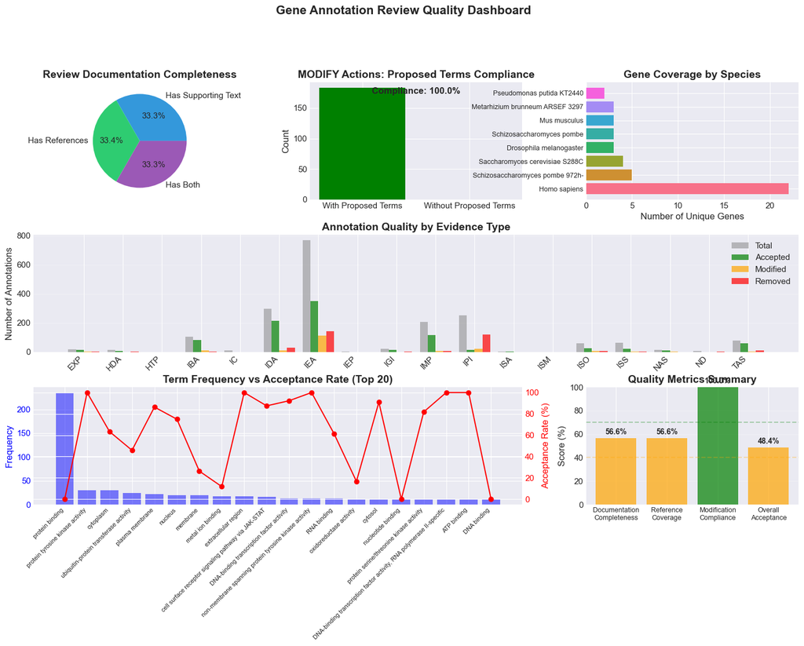

```
🏆 Quality Summary:
━━━━━━━━━━━━━━━━━━━━━━━━━━━━━━━━━━━━━━━━━━━━━━━━━━
⚠️ Documentation Completeness: 56.6%
⚠️ Reference Coverage: 56.6%
✅ Modification Compliance: 100.0%
⚠️ Overall Acceptance: 48.4%
```

```python
# Create a comprehensive quality dashboard
fig = plt.figure(figsize=(18, 10))
gs = fig.add_gridspec(3, 3, hspace=0.3, wspace=0.3)

# Calculate quality metrics
has_supporting_text = df['review_supporting_text'].notna()
has_references = df['review_supporting_reference_ids'].notna()
has_proposed_terms = df['review_proposed_replacement_terms'].notna()
needs_modification = df['review_action'] == 'MODIFY'

# 1. Review completeness pie chart
ax1 = fig.add_subplot(gs[0, 0])
completeness_data = [
    has_supporting_text.sum(),
    has_references.sum(),
    (has_supporting_text & has_references).sum()
]
labels = ['Has Supporting Text', 'Has References', 'Has Both']
ax1.pie(completeness_data, labels=labels, autopct='%1.1f%%',
        colors=['#3498db', '#2ecc71', '#9b59b6'])
ax1.set_title('Review Documentation Completeness', fontweight='bold')

# 2. Modification compliance
ax2 = fig.add_subplot(gs[0, 1])
modify_with_terms = (needs_modification & has_proposed_terms).sum()
modify_without_terms = (needs_modification & ~has_proposed_terms).sum()
ax2.bar(['With Proposed Terms', 'Without Proposed Terms'],
        [modify_with_terms, modify_without_terms],
        color=['green', 'orange'])
ax2.set_title('MODIFY Actions: Proposed Terms Compliance', fontweight='bold')
ax2.set_ylabel('Count')
compliance_rate = modify_with_terms / (modify_with_terms + modify_without_terms) * 100 if needs_modification.sum() > 0 else 0
ax2.text(0.5, ax2.get_ylim()[1] * 0.9, f'Compliance: {compliance_rate:.1f}%',
         ha='center', fontsize=12, fontweight='bold')

# 3. Species coverage
ax3 = fig.add_subplot(gs[0, 2])
species_genes = df.groupby('taxon_label')['gene_symbol'].nunique().sort_values(ascending=False).head(8)
ax3.barh(range(len(species_genes)), species_genes.values,
         color=sns.color_palette("husl", len(species_genes)))
ax3.set_yticks(range(len(species_genes)))
ax3.set_yticklabels(species_genes.index, fontsize=9)
ax3.set_xlabel('Number of Unique Genes')
ax3.set_title('Gene Coverage by Species', fontweight='bold')

# 4. Evidence type quality
ax4 = fig.add_subplot(gs[1, :])
evidence_quality = df.groupby('evidence_type').agg({
    'review_action': [
        ('Total', 'count'),
        ('Accepted', lambda x: (x == 'ACCEPT').sum()),
        ('Modified', lambda x: (x == 'MODIFY').sum()),
        ('Removed', lambda x: (x == 'REMOVE').sum())
    ]
}).reset_index()
evidence_quality.columns = ['Evidence Type', 'Total', 'Accepted', 'Modified', 'Removed']

x = np.arange(len(evidence_quality))
width = 0.2
ax4.bar(x - 1.5*width, evidence_quality['Total'], width, label='Total', color='gray', alpha=0.5)
ax4.bar(x - 0.5*width, evidence_quality['Accepted'], width, label='Accepted', color='green', alpha=0.7)
ax4.bar(x + 0.5*width, evidence_quality['Modified'], width, label='Modified', color='orange', alpha=0.7)
ax4.bar(x + 1.5*width, evidence_quality['Removed'], width, label='Removed', color='red', alpha=0.7)

ax4.set_xticks(x)
ax4.set_xticklabels(evidence_quality['Evidence Type'], rotation=45, ha='right')
ax4.set_ylabel('Number of Annotations')
ax4.set_title('Annotation Quality by Evidence Type', fontweight='bold', fontsize=14)
ax4.legend(loc='upper right')
ax4.grid(axis='y', alpha=0.3)

# 5. Term frequency vs action correlation
ax5 = fig.add_subplot(gs[2, 0:2])
term_frequency = df['term_label'].value_counts()
term_actions = df.groupby('term_label')['review_action'].apply(
    lambda x: (x == 'ACCEPT').mean() * 100
)

# Match indices
common_terms = term_frequency.index.intersection(term_actions.index)
freq_data = term_frequency[common_terms].head(20)
action_data = term_actions[common_terms].head(20)

ax5_twin = ax5.twinx()
bars = ax5.bar(range(len(freq_data)), freq_data.values, alpha=0.5, color='blue', label='Frequency')
line = ax5_twin.plot(range(len(freq_data)), action_data[freq_data.index].values,
                     'ro-', label='Acceptance Rate', markersize=6)

ax5.set_xticks(range(len(freq_data)))
ax5.set_xticklabels(freq_data.index, rotation=45, ha='right', fontsize=8)
ax5.set_ylabel('Frequency', color='blue')
ax5_twin.set_ylabel('Acceptance Rate (%)', color='red')
ax5.set_title('Term Frequency vs Acceptance Rate (Top 20)', fontweight='bold')
ax5.tick_params(axis='y', labelcolor='blue')
ax5_twin.tick_params(axis='y', labelcolor='red')

# 6. Overall quality score
ax6 = fig.add_subplot(gs[2, 2])
quality_scores = {
    'Documentation\nCompleteness': (has_supporting_text.sum() / len(df)) * 100,
    'Reference\nCoverage': (has_references.sum() / len(df)) * 100,
    'Modification\nCompliance': compliance_rate,
    'Overall\nAcceptance': (df['review_action'] == 'ACCEPT').mean() * 100
}

colors_score = ['green' if v >= 70 else 'orange' if v >= 40 else 'red'
                for v in quality_scores.values()]
bars = ax6.bar(range(len(quality_scores)), list(quality_scores.values()),
               color=colors_score, alpha=0.7)
ax6.set_xticks(range(len(quality_scores)))
ax6.set_xticklabels(list(quality_scores.keys()), fontsize=9)
ax6.set_ylabel('Score (%)')
ax6.set_title('Quality Metrics Summary', fontweight='bold')
ax6.axhline(y=70, color='green', linestyle='--', alpha=0.3, label='Good (>70%)')
ax6.axhline(y=40, color='orange', linestyle='--', alpha=0.3, label='Fair (>40%)')
ax6.set_ylim(0, 100)
ax6.grid(axis='y', alpha=0.3)

# Add value labels
for bar, value in zip(bars, quality_scores.values()):
    height = bar.get_height()
    ax6.text(bar.get_x() + bar.get_width()/2., height + 2,
             f'{value:.1f}%', ha='center', va='bottom', fontsize=10, fontweight='bold')

plt.suptitle('Gene Annotation Review Quality Dashboard', fontsize=16, fontweight='bold', y=1.02)
plt.tight_layout()
plt.show()

# Print quality summary
print("\n🏆 Quality Summary:")
print("━" * 50)
for metric, score in quality_scores.items():
    metric_clean = metric.replace('\n', ' ')
    status = "✅" if score >= 70 else "⚠️" if score >= 40 else "❌"
    print(f"{status} {metric_clean}: {score:.1f}%")
```

### What This Shows

Advanced pattern detection to identify:

- **Outlier Genes**: Genes with unusual annotation patterns (e.g., high removal rates)
- **Systematic Biases**: Consistent patterns across species or evidence types
- **Co-occurrence Patterns**: Which evidence types correlate with which actions

### Why This Matters

- Outliers may indicate special cases requiring manual review
- Systematic patterns suggest annotation pipeline issues
- Helps develop targeted improvement strategies

### How It's Calculated

- Statistical outlier detection (>90th percentile removal rates)
- Cross-tabulation and correlation analysis
- Normalized heatmaps to reveal patterns independent of volume

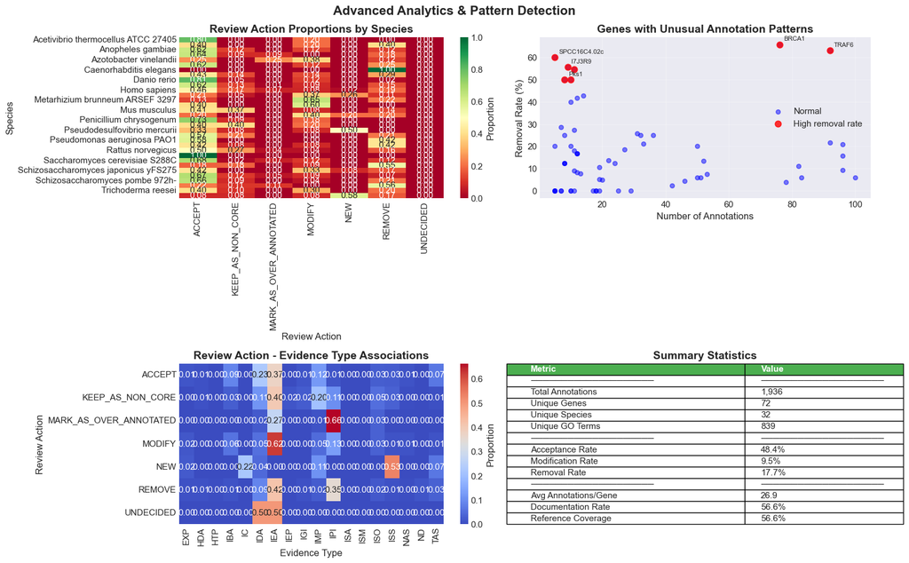

```python
# Advanced analysis: Identify patterns and outliers
fig, axes = plt.subplots(2, 2, figsize=(16, 10))

# 1. Action distribution by species (normalized heatmap)
species_action_norm = pd.crosstab(df['taxon_label'], df['review_action'], normalize='index')
sns.heatmap(species_action_norm, annot=True, fmt='.2f', cmap='RdYlGn',
            ax=axes[0, 0], vmin=0, vmax=1, cbar_kws={'label': 'Proportion'})
axes[0, 0].set_title('Review Action Proportions by Species', fontweight='bold')
axes[0, 0].set_xlabel('Review Action')
axes[0, 0].set_ylabel('Species')

# 2. Outlier detection - genes with unusual patterns
gene_pattern = df.groupby('gene_symbol').agg({
    'review_action': lambda x: (x == 'REMOVE').mean() * 100,
    'term_id': 'count'
}).reset_index()
gene_pattern.columns = ['gene', 'removal_rate', 'n_annotations']
gene_pattern = gene_pattern[gene_pattern['n_annotations'] >= 5]  # Filter for statistical significance

# Identify outliers (high removal rate)
outliers = gene_pattern[gene_pattern['removal_rate'] > gene_pattern['removal_rate'].quantile(0.9)]

axes[0, 1].scatter(gene_pattern['n_annotations'], gene_pattern['removal_rate'],
                   alpha=0.5, s=30, color='blue', label='Normal')
axes[0, 1].scatter(outliers['n_annotations'], outliers['removal_rate'],
                   alpha=0.8, s=60, color='red', label='High removal rate')

# Annotate outliers
for _, row in outliers.head(5).iterrows():
    axes[0, 1].annotate(row['gene'], (row['n_annotations'], row['removal_rate']),
                        xytext=(5, 5), textcoords='offset points', fontsize=8)

axes[0, 1].set_xlabel('Number of Annotations')
axes[0, 1].set_ylabel('Removal Rate (%)')
axes[0, 1].set_title('Genes with Unusual Annotation Patterns', fontweight='bold')
axes[0, 1].legend()
axes[0, 1].grid(True, alpha=0.3)

# 3. Co-occurrence matrix of review actions and evidence types
action_evidence_matrix = pd.crosstab(df['review_action'], df['evidence_type'])
action_evidence_norm = action_evidence_matrix.div(action_evidence_matrix.sum(axis=1), axis=0)

sns.heatmap(action_evidence_norm, annot=True, fmt='.2f', cmap='coolwarm',
            ax=axes[1, 0], cbar_kws={'label': 'Proportion'})
axes[1, 0].set_title('Review Action - Evidence Type Associations', fontweight='bold')
axes[1, 0].set_xlabel('Evidence Type')
axes[1, 0].set_ylabel('Review Action')

# 4. Summary statistics table
axes[1, 1].axis('tight')
axes[1, 1].axis('off')

summary_data = [
    ['Metric', 'Value'],
    ['─' * 20, '─' * 20],
    ['Total Annotations', f'{len(df):,}'],
    ['Unique Genes', f'{df["gene_symbol"].nunique()}'],
    ['Unique Species', f'{df["taxon_label"].nunique()}'],
    ['Unique GO Terms', f'{df["term_id"].nunique()}'],
    ['─' * 20, '─' * 20],
    ['Acceptance Rate', f'{(df["review_action"] == "ACCEPT").mean() * 100:.1f}%'],
    ['Modification Rate', f'{(df["review_action"] == "MODIFY").mean() * 100:.1f}%'],
    ['Removal Rate', f'{(df["review_action"] == "REMOVE").mean() * 100:.1f}%'],
    ['─' * 20, '─' * 20],
    ['Avg Annotations/Gene', f'{df.groupby("gene_symbol")["term_id"].count().mean():.1f}'],
    ['Documentation Rate', f'{has_supporting_text.mean() * 100:.1f}%'],
    ['Reference Coverage', f'{has_references.mean() * 100:.1f}%']
]

table = axes[1, 1].table(cellText=summary_data, cellLoc='left', loc='center',
                        colWidths=[0.6, 0.4])
table.auto_set_font_size(False)
table.set_fontsize(11)
table.scale(1.2, 1.5)

# Style the header
for i in range(2):
    table[(0, i)].set_facecolor('#4CAF50')
    table[(0, i)].set_text_props(weight='bold', color='white')

axes[1, 1].set_title('Summary Statistics', fontweight='bold', fontsize=14)

plt.suptitle('Advanced Analytics & Pattern Detection', fontsize=16, fontweight='bold')
plt.tight_layout()
plt.show()
```

## 💡 Key Insights & Recommendations

### What This Shows

Automated generation of actionable insights based on the statistical analyses above. Identifies:

- Top-performing and problematic areas
- Specific genes, terms, or evidence types needing attention
- Concrete recommendations for improving annotation quality

### How Recommendations Are Generated

- Thresholds trigger specific recommendations (e.g., >30% modification rate)
- Identifies bottom performers in each category
- Prioritizes high-impact improvements

### Using These Insights

These recommendations should guide:

1. **Immediate Actions**: Fix compliance issues, review problematic terms
2. **Process Improvements**: Update curation guidelines, retrain annotators
3. **Strategic Planning**: Resource allocation, tool development priorities

```python
# Generate automated insights
print("\n" + "="*60)
print("📊 KEY INSIGHTS FROM GENE ANNOTATION REVIEW")
print("="*60)

# Calculate key metrics
total_annotations = len(df)
acceptance_rate = (df['review_action'] == 'ACCEPT').mean() * 100
modification_rate = (df['review_action'] == 'MODIFY').mean() * 100
removal_rate = (df['review_action'] == 'REMOVE').mean() * 100

# Evidence type insights
evidence_accept = df.groupby('evidence_type')['review_action'].apply(
    lambda x: (x == 'ACCEPT').mean() * 100
).sort_values(ascending=False)

print("\n🎯 Overall Performance:")
print(f"  • {acceptance_rate:.1f}% of annotations were accepted as-is")
print(f"  • {modification_rate:.1f}% need modifications")
print(f"  • {removal_rate:.1f}% should be removed")

print("\n🔬 Evidence Type Analysis:")
print(f"  • Most reliable evidence: {evidence_accept.index[0]} ({evidence_accept.iloc[0]:.1f}% acceptance)")
print(f"  • Least reliable evidence: {evidence_accept.index[-1]} ({evidence_accept.iloc[-1]:.1f}% acceptance)")

# Species insights
species_stats = df.groupby('taxon_label').agg({
    'review_action': lambda x: (x == 'ACCEPT').mean() * 100,
    'gene_symbol': 'nunique'
}).sort_values('review_action', ascending=False)

print("\n🧬 Species Quality Rankings:")
for i, (species, row) in enumerate(species_stats.head(3).iterrows(), 1):
    print(f"  {i}. {species}: {row['review_action']:.1f}% acceptance ({row['gene_symbol']} genes)")

# Problem areas
print("\n⚠️ Areas Requiring Attention:")

# Terms with high modification rates
problem_terms = df[df['review_action'].isin(['MODIFY', 'REMOVE'])].groupby('term_label').size()
problem_terms = problem_terms.sort_values(ascending=False).head(3)

print("  Most problematic GO terms:")
for term, count in problem_terms.items():
    print(f"    • {term}: {count} issues")

# Compliance issues
modify_compliance = (df[df['review_action'] == 'MODIFY']['review_proposed_replacement_terms'].notna()).mean() * 100
print(f"\n  Modification compliance: {modify_compliance:.1f}% have proposed replacements")

print("\n✅ Recommendations:")
if modification_rate > 30:
    print("  1. High modification rate suggests need for annotation guidelines review")
if removal_rate > 20:
    print("  2. High removal rate indicates quality control issues in original annotations")
if modify_compliance < 80:
    print("  3. Improve documentation of proposed replacement terms for modifications")
if evidence_accept.iloc[-1] < 50:
    print(f"  4. Review {evidence_accept.index[-1]} evidence type annotations more carefully")

print("\n" + "="*60)
```

```
============================================================
📊 KEY INSIGHTS FROM GENE ANNOTATION REVIEW
============================================================

🎯 Overall Performance:
  • 48.4% of annotations were accepted as-is
  • 9.5% need modifications
  • 17.7% should be removed

🔬 Evidence Type Analysis:
  • Most reliable evidence: ISA (100.0% acceptance)
  • Least reliable evidence: HTP (0.0% acceptance)

🧬 Species Quality Rankings:
  1. Ruminiclostridium josui: 100.0% acceptance (1.0 genes)
  2. Danio rerio: 81.0% acceptance (1.0 genes)
  3. Acetivibrio thermocellus ATCC 27405: 80.0% acceptance (1.0 genes)

⚠️ Areas Requiring Attention:
  Most problematic GO terms:
    • protein binding: 143 issues
    • ubiquitin-protein transferase activity: 13 issues
    • metal ion binding: 12 issues

  Modification compliance: 100.0% have proposed replacements

✅ Recommendations:
  4. Review HTP evidence type annotations more carefully

============================================================
```